# MLB linear Regression

Linear Regression of MLB salaries in correlation to various features

Pranav Thaenraj

# Introduction

This dataset is a random sample of 353 records from the MLB that provides the salary, years of experience, batting average,avg games per year, home runs per year, and runs batted in a year

The features given in this dataset naturally fall in two categories, they are either indicators of experience (years of experience, career batting average) or they are indicators of performance (avg games per year, home runs per year, runs batted in a year). In this project I will first use linear regression models for single features against salary in an attempt to find the best feature to predict the salary of a player in the MLB. After this I will use multiple regressions models to see if features that indicate experience or those that indicate performance or the combination of all features provides the best model for predicting salaries

```r
# Loading data
mlb = read.csv("mlb.csv")
head(mlb)
```

|  | salary | years | bavg | gamesyr | hrnsyr | rbisyr |
| --- | --- | --- | --- | --- | --- | --- |
| 1 | 6329213 | 12 | 289 | 142.08330 | 19.250000 | 69.66666 |
| 2 | 3375000 | 8 | 259 | 114.75000 | 9.125000 | 42.75000 |
| 3 | 3100000 | 5 | 299 | 150.20000 | 9.200000 | 71.00000 |
| 4 | 2900000 | 8 | 245 | 132.00000 | 13.375000 | 52.62500 |
| 5 | 1650000 | 12 | 258 | 99.66666 | 10.333330 | 45.08333 |
| 6 | 700000 | 17 | 286 | 119.52940 | 2.352941 | 33.76471 |

```r
#Initial Exploratory Analysis
mlb_df <- as.data.frame(mlb)
#DataFrame with 6 columns and 353 records
class(mlb_df)
```

```
[1] "data.frame"
```

```r
dim(mlb_df)
```

```
[1] 353   6
```

```r
#Summary statistics for all columns of mlb_df
summary(mlb_df)
```

```
     salary            years             bavg
 Min.   : 109000   Min.   : 1.000   Min.   :111
 1st Qu.: 253600   1st Qu.: 3.000   1st Qu.:245
 Median : 675000   Median : 6.000   Median :259
 Mean   :1345672   Mean   : 6.326   Mean   :259
 3rd Qu.:2250000   3rd Qu.: 9.000   3rd Qu.:275
 Max.   :6329213   Max.   :20.000   Max.   :625
    gamesyr           hrnsyr           rbisyr
 Min.   :  5.50   Min.   : 0.000   Min.   : 0.50
 1st Qu.: 65.00   1st Qu.: 1.700   1st Qu.:17.67
 Median : 94.67   Median : 5.167   Median :31.40
 Mean   : 90.08   Mean   : 7.119   Mean   :35.05
 3rd Qu.:117.00   3rd Qu.:10.333   3rd Qu.:48.22
 Max.   :159.00   Max.   :31.429   Max.   :97.62
```

```r
#removing null values (data clean)
mlb_df = na.omit(mlb_df)
dim(mlb_df)
```

```
[1] 353   6
```

# Visual data Analysis

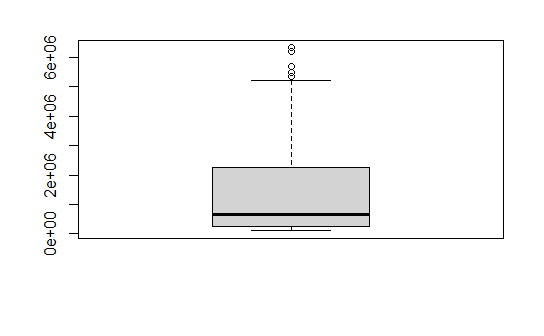

```r
#Visual Statistics
boxplot(mlb_df$salary)
```

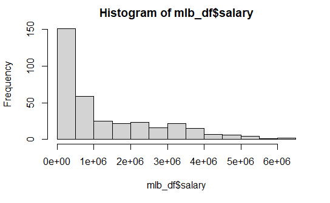

```r
hist(mlb_df$salary)
```

The histogram of the salaries of the MLB players in this dataset is shown to be skewed to the right. The Box plot shows that there are a few outliers which seems to contribute to the skewed nature of the dataset

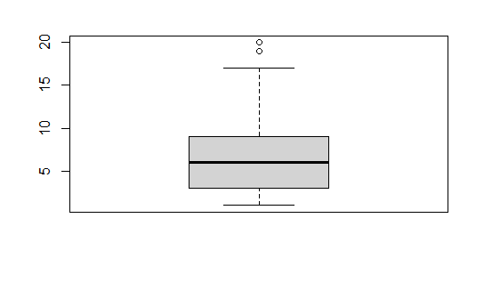

```r
boxplot(mlb_df$years)
```

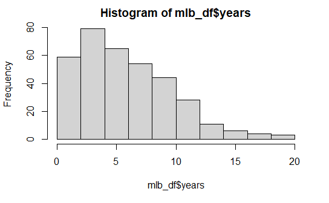

```r
hist(mlb_df$years)
```

The Histogram of the number of years a player has played is skewed slightly to the right this is can be associated with the number of outliers in the dataset, which can be seen in the boxplot

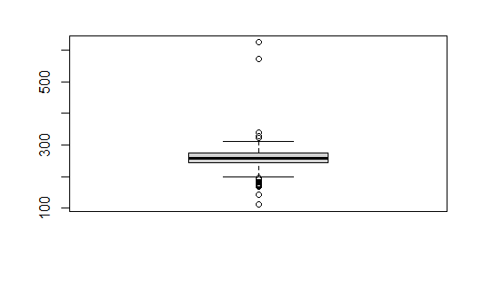

```r
boxplot(mlb_df$bavg)
```

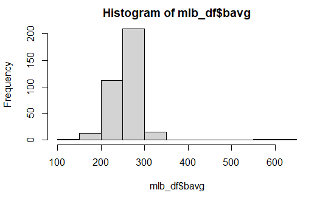

```r
hist(mlb_df$bavg)
```

The Batting average of the players in this dataset is more or less normally distributed. This may be attributed to the large number of outliers on both ends of the boxplot

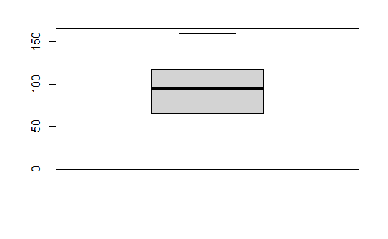

```r
boxplot(mlb_df$gamesyr)
```

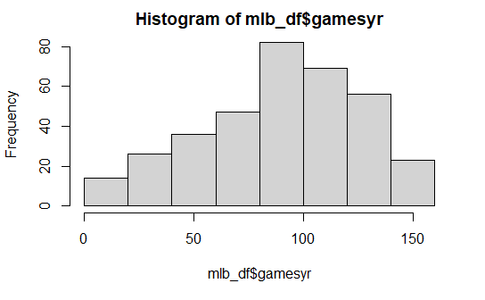

```r
hist(mlb_df$gamesyr)
```

The histogram of games per year is slightly skewed to the left

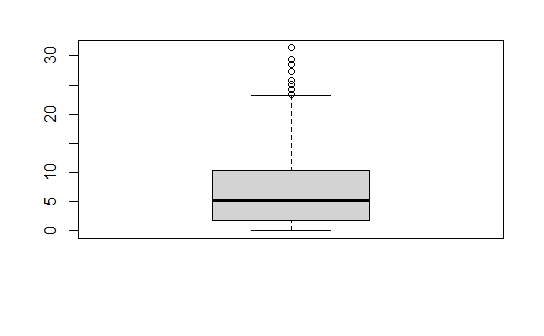

```r
boxplot(mlb_df$hrnsyr)
```

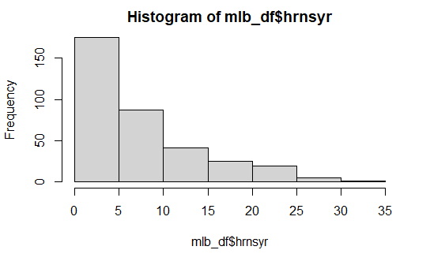

```r
hist(mlb_df$hrnsyr)
```

The histogram of homeruns per year is heavily skewed to the right indicatng that most players tended to score a low number of home runs per year

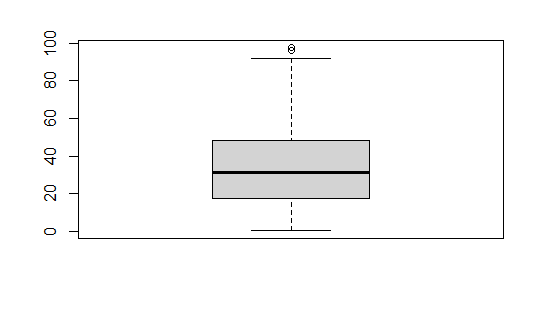

```r
boxplot(mlb_df$rbisyr)
```

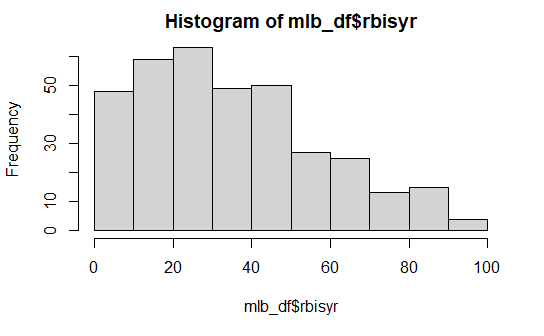

```r
hist(mlb_df$rbisyr)
```

The Histogram of runs batted in a year is skewed to the right indicating that most players tended to not score runs in the higher range of runs

# Single Variable Least Squares Regressions

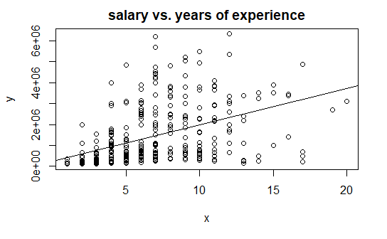

```r
#plotting salary and years and finding regressin line
y = mlb_df$salary
x = mlb_df$years
plot(x,y, main = "salary vs. years of experience")
reg_line <- lm(y~x)
abline( 248601,173429)
```

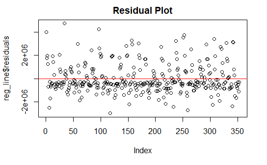

```r
#Residual plot of regression model
plot(reg_line$residuals, main ="Residual Plot")
abline(h=0, col = "red")
```

```r
summary(reg_line)
```

```
Call:
lm(formula = y ~ x)

Residuals:
     Min       1Q   Median       3Q      Max
-2971888  -665744  -382887   545184  4737399

Coefficients:
            Estimate Std. Error t value Pr(>|t|)
(Intercept)   248601     126132   1.971   0.0495 *
x             173429      17003  10.200   <2e-16 ***
---
Signif. codes:  0 ‘***’ 0.001 ‘**’ 0.01 ‘*’ 0.05 ‘.’ 0.1 ‘ ’ 1

Residual standard error: 1238000 on 351 degrees of freedom
Multiple R-squared:  0.2286,    Adjusted R-squared:  0.2264
F-statistic:   104 on 1 and 351 DF,  p-value: < 2.2e-16
```

A linear regression model that models salary over years of experience. The equation of this particular model is:

Salary = 248601 + 173429(years of experience)

The residual plot for this regression line shows that most values with a low residual are beneath the predicted value and the values with the high residual tend to be farther off from the predicted values

The residual standard error for this model is: 1238000

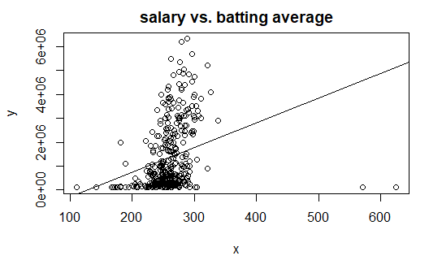

```r
#Plotting Salary and Batting Average
y = mlb_df$salary
x = mlb_df$bavg
plot(x,y, main = "salary vs. batting average")
reg_line <- lm(y~x)
#reg_line
abline(-1328495,10326)
```

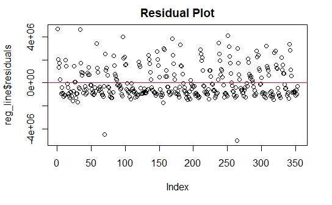

```r
#Residual plot of regression model
plot(reg_line$residuals, main ="Residual Plot")
abline(h=0, col = "red")
```

```r
summary(reg_line)
```

```
Call:
lm(formula = y ~ x)

Residuals:
     Min       1Q   Median       3Q      Max
-5015964  -930063  -508031   776291  4673628

Coefficients:
            Estimate Std. Error t value Pr(>|t|)
(Intercept) -1328495     491105  -2.705  0.00716 **
x              10326       1876   5.505 7.15e-08 ***
---
Signif. codes:  0 ‘***’ 0.001 ‘**’ 0.01 ‘*’ 0.05 ‘.’ 0.1 ‘ ’ 1

Residual standard error: 1352000 on 351 degrees of freedom
Multiple R-squared:  0.07947,   Adjusted R-squared:  0.07684
F-statistic:  30.3 on 1 and 351 DF,  p-value: 7.153e-08
```

A linear regression model that models salary over batting average. The equation of this particular model is:

Salary = -1328495 + 10326(batting average)

While the residual plot of this particular regression model shows that this prediction is not a bad one the scatter plot shows that the data tends to stop at a certain point and that extrapolating the data based on the regression line past this point may not be effective

The residual standard error for this model is: 1352000

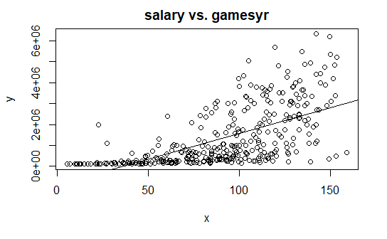

```r
#Plotting Salary and gamesyr
y = (mlb_df$salary)
x = (mlb_df$gamesyr)
plot(x,y, main = "salary vs. gamesyr")
reg_line <- lm(y~x)
#reg_line
abline(-869718, 24595)
```

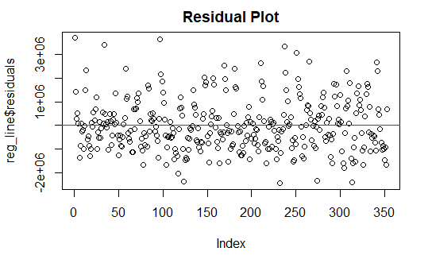

```r
#Residual plot of regression model
plot(reg_line$residuals, main ="Residual Plot")
abline(h=0, col = "red")
```

```r
summary(reg_line)
```

```
Call:
lm(formula = y ~ x)

Residuals:
     Min       1Q   Median       3Q      Max
-2444887  -777382  -149637   539716  3704440

Coefficients:
            Estimate Std. Error t value Pr(>|t|)
(Intercept)  -869718     156427   -5.56 5.35e-08 ***
x              24595       1612   15.26  < 2e-16 ***
---
Signif. codes:  0 ‘***’ 0.001 ‘**’ 0.01 ‘*’ 0.05 ‘.’ 0.1 ‘ ’ 1

Residual standard error: 1093000 on 351 degrees of freedom
Multiple R-squared:  0.3987,    Adjusted R-squared:  0.397
F-statistic: 232.8 on 1 and 351 DF,  p-value: < 2.2e-16
```

A linear regression model that models salary over games for year. The equation of this particular model is:

Salary = -869718 + 24595(games for year)

While this plot is seemingly nonlinear the regression line is seeminly efficient in serving as a predictor of salary based on the results from the residual plot

The residual standard error for this model is: 1093000

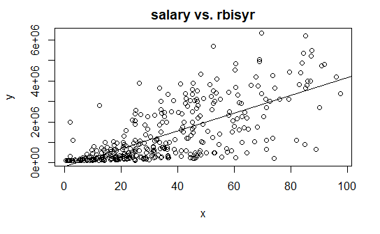

```r
#Plotting Salary and gamesyr
y = mlb_df$salary
x = mlb_df$rbisyr
plot(x,y, main = "salary vs. rbisyr")
reg_line <- lm(y~x)
abline( -183078, 43616)
```

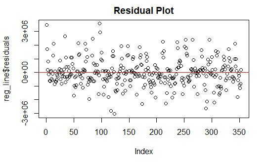

```r
#Residual plot of regression model
plot(reg_line$residuals, main ="Residual Plot")
abline(h=0, col = "red")
```

```r
summary(reg_line)
```

```
Call:
lm(formula = y ~ x)

Residuals:
     Min       1Q   Median       3Q      Max
-3043747  -563974   -64778   394716  3590122

Coefficients:
            Estimate Std. Error t value Pr(>|t|)
(Intercept)  -183078      97231  -1.883   0.0605 .
x              43616       2326  18.756   <2e-16 ***
---
Signif. codes:  0 ‘***’ 0.001 ‘**’ 0.01 ‘*’ 0.05 ‘.’ 0.1 ‘ ’ 1

Residual standard error: 996000 on 351 degrees of freedom
Multiple R-squared:  0.5006,    Adjusted R-squared:  0.4991
F-statistic: 351.8 on 1 and 351 DF,  p-value: < 2.2e-16
```

A linear regression model that models salary over rbisyr. The equation of this particular model is:

Salary = -183078 + 43616(rbisyr)

The residual plot for this particular model shows that it is an excellent predictor of salary.

The residual standard error for this model is: 996000, indicating that the model is better than all others so far as a predictor of salary

# Multiple Regressions models

```r
#multiple regression model
y = mlb_df$salary
x1 = mlb_df$years
x2 = mlb_df$bavg
x3 = mlb_df$gamesyr
x4 = mlb_df$hrnsyr
x5 = mlb_df$rbisyr
fit <- lm(y~x1+x2+x3+x4+x5, data = mlb_df)
summary(fit)
```

```
Call:
lm(formula = y ~ x1 + x2 + x3 + x4 + x5, data = mlb_df)

Residuals:
     Min       1Q   Median       3Q      Max
-3314683  -560404   -46777   457090  3600570

Coefficients:
            Estimate Std. Error t value Pr(>|t|)
(Intercept)  -934893     387536  -2.412 0.016366 *
x1             60629      16255   3.730 0.000224 ***
x2              2030       1481   1.371 0.171311
x3              2254       3551   0.635 0.526100
x4             17892      21545   0.830 0.406856
x5             29700       9627   3.085 0.002199 **
---
Signif. codes:  0 ‘***’ 0.001 ‘**’ 0.01 ‘*’ 0.05 ‘.’ 0.1 ‘ ’ 1

Residual standard error: 974900 on 347 degrees of freedom
Multiple R-squared:  0.527, Adjusted R-squared:  0.5201
F-statistic: 77.31 on 5 and 347 DF,  p-value: < 2.2e-16
```

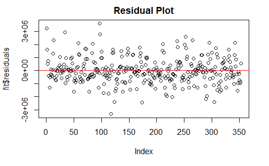

```r
plot(fit$residuals, main = "Residual Plot")
abline(h=0, col = "red")
```

The Equation of this multiple regression model is:

salary = -934893 + yearsofExp(60629) + BattingAvg(2030) + gamesPerYear(2254) + homerunsPerYear(17892) + runsBattedYearly(29700)

Of all regression models made so far this particular model has a low Residual Standard Error: 974900

```r
#multiple regression model using player experience features only
y = mlb_df$salary
x1 = mlb_df$years
x2 = mlb_df$bavg

fit <- lm(y~x1+x2, data = mlb_df)
summary(fit)
```

```
Call:
lm(formula = y ~ x1 + x2, data = mlb_df)

Residuals:
     Min       1Q   Median       3Q      Max
-3003810  -661912  -326343   506304  4603746

Coefficients:
            Estimate Std. Error t value Pr(>|t|)
(Intercept) -1514380     439833  -3.443 0.000645 ***
x1            159463      16952   9.407  < 2e-16 ***
x2              7148       1712   4.176 3.75e-05 ***
---
Signif. codes:  0 ‘***’ 0.001 ‘**’ 0.01 ‘*’ 0.05 ‘.’ 0.1 ‘ ’ 1

Residual standard error: 1210000 on 350 degrees of freedom
Multiple R-squared:  0.2652,    Adjusted R-squared:  0.261
F-statistic: 63.17 on 2 and 350 DF,  p-value: < 2.2e-16
```

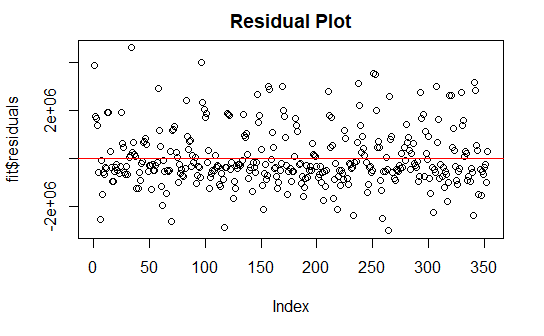

```r
plot(fit$residuals, main = "Residual Plot")
abline(h=0, col = "red")
```

The multiple regression model that considers only features that relate to player experience seems to not be a very good prediction at first glance of the residual plot. Most points on the residual plot are underneath the abline, meaning that the predicted value of the majority of values in the model is greater than their actual values. this is an indication of a large number of outliers in the data of players’ years of experience and career batting average. The residual plot is indicative of the experience not being the best predictor of salary

The equation of this multiple regressions model is:

salary = -1514380 + yearsofExp(159463) + BattingAvg(7148)

The residual standard error for this model is: 1210000, a value that is much higher than that of the model that utilized all features to predict salary, Thus indicating that the usage of mere features indicative of experience may not be the best way to predict a player’s salary and that the player’s performance is an important component in predicting the players salary

```r
#multiple regression model using player performance features only
y = mlb_df$salary
x1 = mlb_df$gamesyr
x2 = mlb_df$hrnsyr
x3 = mlb_df$rbisyr

fit <- lm(y~x1+x2+x3, data = mlb_df)
summary(fit)
plot(fit$residuals, main = "Residual Plot")
abline(h=0, col = "red")
```

[output not shown]

The equation of this multiple regressions model is:

salary = -400680 + gamesPerYear(5897) + homerunsPerYear(16518) + runsBattedYearly(31314)

The residual standard error for this model is: 994600, a value that is higher than that of the model that utilized all features but lower than that of the model that utilized only features that indicated player experience.

# Conclusion

Thus through the analysis of all three of these multiple regression models and their respective residual standard errors one can deem that while a player’s performance is more important in the prediction of their salary, the experience that a player has is also an important feature to consider. This can be corroborated by thinking of players that are currently in the MLB. A player with very strong performance statistics early in his career has the potential to earn a high salary, but a player with the same statistics and a larger amount of experience is logically bound to make more money because this player not only has shown consistency throughout their career with their good performance, but has potentially been on a particular team for a very long time and is a favorite of the fans of said team. Thus in conclusion, one can deem that the best predictor of a players salary comes from the analysis of both the player’s statistics that are in regard to their experience as well as their performance